# In the name of God

## Feed Forward Neural Network

## Name: Marzieh Bagherinia Amiri

#### Spring 1400

```python
import random
import numpy as np
import pandas as pd
import matplotlib.pyplot as plt
from copy import deepcopy
from termcolor import colored

Euler = 2.71828182845904523536
```

# Dataloader

```python
class Dataloader:

    def __init__(self, data, labels, n_classes, batch_size=None, shuffle=False):

        assert len(data)==len(labels)
        self.__n_classes = n_classes
        self.__batch_size = batch_size
        self.__shuffle = shuffle
        self.__data = data
        self.__onehot_labels = self.__onehot(labels, self.__n_classes)

    def __onehot(self, labels, n_classes):
        onehot_vectors = np.zeros((len(labels), n_classes))

        for i in range(len(labels)):
            for j in range(n_classes):
                if(j == labels[i]):
                    onehot_vectors[i, j] = 1

        return onehot_vectors

    def __shuffle_dataset(self):
        rng_state = np.random.get_state()
        np.random.shuffle(self.__data)
        np.random.set_state(rng_state)
        np.random.shuffle(self.__onehot_labels)

    def __iter__(self):

        if self.__shuffle:
            self.__shuffle_dataset()

        if self.__batch_size==None:
            yield (np.matrix(self.__data), np.matrix(self.__onehot_labels))
            return

        for idx in range(0, len(self.__data), self.__batch_size):
            yield (np.matrix(self.__data[idx:idx+self.__batch_size]),
                   np.matrix(self.__onehot_labels[idx:idx+self.__batch_size]))
```

# Activation Functions

```python
class Identical:

    def __init__(self): pass

    def __val(self, matrix):
        identical_value = np.matrix(matrix, dtype=float)
        return identical_value

    def derivative(self, matrix):
        temp = np.matrix(matrix, dtype=float)
        identical_derivative = np.matrix(np.full(np.shape(temp), 1.))
        return identical_derivative

    def __call__(self, matrix):
        return self.__val(matrix)

class Relu:

    def __init__(self): pass

    def __val(self, matrix):
        matrix = matrix.copy()
        matrix[matrix<0] = 0
        return np.matrix(matrix)

    def derivative(self, matrix):
        matrix = matrix.copy()
        matrix[matrix<0] = 0
        matrix[matrix>0] = 1
        return np.matrix(matrix)

    def __call__(self, matrix):
        return self.__val(matrix)

class LeakyRelu:

    def __init__(self, negative_slope=0.01):
        self.negative_slope = negative_slope

    def __val(self, matrix):
        matrix = matrix.copy()
        return np.matrix( np.maximum(matrix, matrix*self.negative_slope) )

    def derivative(self, matrix):
        matrix = matrix.copy()
        matrix[matrix > 0] = 1
        matrix[matrix < 0] = self.negative_slope
        return np.matrix(matrix)

    def __call__(self, matrix):
        return self.__val(matrix)

class Sigmoid:

    def __init__(self): pass

    def __val(self, matrix):
        sigmoid_value = np.zeros(matrix.shape, dtype=np.float64)
        for i in range(len(sigmoid_value)):
            for j in range(len(sigmoid_value[i])):
                sigmoid_value[i, j] = 1 / (1 + (Euler ** (-matrix[i, j])))
        return sigmoid_value

    def derivative(self, matrix):
        sigmoid_value = self.__val(matrix)
        sigmoid_derivative = np.multiply(sigmoid_value, 1 - sigmoid_value)
        return sigmoid_derivative

    def __call__(self, matrix):
        return self.__val(matrix)

class Softmax:

    def __init__(self): pass

    def __val(self, matrix):
        matrix = matrix.copy()
        matrix = np.exp(matrix-np.max(matrix,-1))
        return np.divide(matrix, np.matrix(np.sum(matrix, axis=1)))

    def derivative(self, matrix):
        matrix = matrix.copy()
        matrix = self(matrix)
        return np.multiply(matrix, 1.0-matrix)

    def __call__(self, matrix):
        return self.__val(matrix)

class Tanh:

    def __init__(self): pass

    def __val(self, matrix):
        return np.matrix((np.exp(matrix)-np.exp(-1*matrix))/((np.exp(matrix)+np.exp(-1*matrix))))

    def derivative(self, matrix):
        tanh = self.__val(matrix)
        return np.matrix(1-np.multiply(tanh, tanh))

    def __call__(self, matrix):
        return self.__val(matrix)
```

# Loss Functions

```python
class CrossEntropy: #(with softmax)

    def __init__(self): pass

    def __val(self, true_val, expected_val):
        assert np.shape(true_val)==np.shape(expected_val)
        softmax = Softmax()
        epsilon = 0.00000000000001
        cross_entropy_value = np.multiply(-expected_val, np.log(np.clip(softmax(true_val), epsilon, 1 - epsilon))).sum(axis = 1) #swap(true_val, expected_val)
        return cross_entropy_value

    def derivative(self, true_val, expected_val):
        assert np.shape(true_val)==np.shape(expected_val)
        softmax = Softmax()
        epsilon = 0.0000000000001
        cross_entropy_derivative = np.subtract(np.clip(softmax(true_val), epsilon, 1 - epsilon), expected_val)
        return cross_entropy_derivative

    def __call__(self, true_val, expected_val):
        return self.__val(true_val, expected_val)
```

# Layer

```python
class Layer:

    DEFAULT_LOW, DEFAULT_HIGH, DEFAULT_MEAN, DEFAULT_VAR = 0, 0.05, 0., 1.

    def __init__(self, input_size, output_size,
                 activation=Identical(), initial_weight='uniform', **initializing_parameters):

        assert type(initial_weight)==str, 'Undefined activation function!'

        self.__weight_initializer_dict = {'uniform':self.__uniform_weight, 'normal':self.__normal_weight, 'same':self.__same_weight}

        assert initial_weight in self.__weight_initializer_dict, 'Undefined weight initialization function!'


        self.__n_neurons = output_size
        weight_initializer = self.__weight_initializer_dict[initial_weight]
        self.__weight = weight_initializer(input_size, self.__n_neurons, **initializing_parameters)
        self.__bias = weight_initializer(1, self.__n_neurons, **initializing_parameters)
        self.__activation = activation

        self.__last_input = 0
        self.__last_activation_input = 0
        self.__last_activation_output = 0
        self.__last_activation_derivative = 0
        self.__last_weights_update = 0
        self.__last_bias_update = 0

    def forward(self, layer_input):
        assert np.ndim(layer_input)==2
        assert np.size(self.__weight,0) == np.size(layer_input,1)
        self.__last_input = layer_input
        self.__last_activation_input = np.matmul(layer_input, self.__weight) + self.__bias
        self.__last_activation_output = self.activation(self.__last_activation_input)
        self.__last_activation_derivative = self.activation.derivative(self.__last_activation_input)
        return self.__last_activation_output

    def update_weights(self, backprop_tensor, lr):
        assert np.ndim(backprop_tensor)==2
        assert np.size(backprop_tensor,0) == np.size(self.__last_activation_derivative,0)
        assert np.size(backprop_tensor,1) == self.__n_neurons

        xt = self.__last_input.transpose()
        yp = np.multiply(backprop_tensor, self.__last_activation_derivative)
        bt = np.matrix(np.tile(1, (1, yp.shape[0])))
        wp = np.matmul(xt, yp)
        bp = np.matmul(bt, yp)

        backprop_tensor = np.matmul(yp, self.__weight.transpose())

        self.__weight -= wp * lr
        self.__bias -= bp * lr

        return backprop_tensor

    def __uniform_weight(self, dim1, dim2, **initializing_parameters):
        low, high = self.DEFAULT_LOW, self.DEFAULT_HIGH
        if 'low' in initializing_parameters.keys(): low = initializing_parameters['low']
        if 'high' in initializing_parameters.keys(): high = initializing_parameters['high']
        weights = np.random.uniform(low = low, high = high, size = (dim1, dim2))
        return weights

    def __normal_weight(self, dim1, dim2, **initializing_parameters):
        mean, var = self.DEFAULT_MEAN, self.DEFAULT_VAR
        if 'mean' in initializing_parameters.keys(): mean = initializing_parameters['mean']
        if 'var' in initializing_parameters.keys(): var = initializing_parameters['var']
        weights = np.random.normal(loc = mean, scale = var, size = (dim1, dim2))
        return weights

    def __same_weight(self, dim1, dim2, **initializing_parameters):
        value = 0
        if 'value' in initializing_parameters.keys(): value = initializing_parameters['value']
        weights = np.matrix(np.zeros([dim1, dim2])) + value
        return weights

    @property
    def n_neurons(self): return self.__n_neurons

    @property
    def weight(self): return self.__weight

    @property
    def bias(self): return self.__bias

    @property
    def activation(self): return self.__activation
```

# Feed Forward Neural Network

```python
class FeedForwardNN:

    def __init__(self, input_shape):

        self.__input_shape = input_shape
        self.__output_shape = None

        self.__layers_list = []

        self.__lr = None
        self.__loss = None

    def add_layer(self, n_neurons, activation=Relu(), initial_weight='uniform', **initializing_parameters):

        assert type(n_neurons)==int, "Invalid number of neurons for the layer!"
        assert n_neurons>0, "Invalid number of neurons for the layer!"

        n_prev_neurons = self.__input_shape if len(self.__layers_list)==0 else self.__layers_list[-1].n_neurons
        new_layer = Layer(n_prev_neurons, n_neurons, activation, initial_weight, **initializing_parameters)
        self.__layers_list.append(new_layer)
        self.__output_shape = self.__layers_list[-1].n_neurons

    def set_training_param(self, loss=CrossEntropy(), lr=1e-3):
        assert self.__layers_list, "Uncomplete model!"
        self.__loss = loss
        self.__lr = lr

    def forward(self, network_input):
        assert type(self.__output_shape) != None, "Model is not compiled!"
        network_output = deepcopy(network_input)

        for layer in self.__layers_list:
            network_output = layer.forward(network_output)

        return network_output

    def fit(self, epochs, trainloader, testloader=None, print_results=True):

        assert type(self.__output_shape) != None, "Model is not compiled!"
        assert type(self.__lr) != None and type(self.__loss) != None, "Training paramenters are not set!"

        log = {"train_accuracy":[], "train_loss":[], "test_accuracy":[], "test_loss":[]}

        for epoch in range(1, epochs+1):

            if print_results:
                print('Epoch {}:'.format(epoch))

            average_accuracy, average_loss = self.__train(trainloader)
            log['train_accuracy'].append(average_accuracy)
            log['train_loss'].append(average_loss)
            if print_results:
                print('\tTrain: Average Accuracy: {}\tAverage Loss: {}'.format(average_accuracy, average_loss))

            if type(testloader) != type(None):
                average_accuracy, average_loss = self.__test(testloader)
                log['test_accuracy'].append(average_accuracy)
                log['test_loss'].append(average_loss)
                if print_results:
                    print('\tTest: Average Accuracy: {}\tAverage Loss: {}'.format(average_accuracy, average_loss))

        return log

    def __train(self, trainloader):
        bach_accuracies, batch_losses = [], []
        for x_train, y_train in trainloader:
            batch_accuracy, batch_loss = self.__train_on_batch(x_train, y_train)
            bach_accuracies.append(batch_accuracy)
            batch_losses.append(batch_loss)
        return np.mean(bach_accuracies), np.mean(batch_losses)

    def __test(self, testloader):
        bach_accuracies, batch_losses = [], []
        for x_test, y_test in testloader:
            batch_accuracy, batch_loss = self.__test_on_batch(x_test, y_test)
            bach_accuracies.append(batch_accuracy)
            batch_losses.append(batch_loss)
        return np.mean(bach_accuracies), np.mean(batch_losses)

    def __train_on_batch(self, x_batch, y_batch):
        output_batch = self.forward(x_batch)
        batch_average_loss = self.__update_weights(output_batch, y_batch)
        batch_accuracy = self.__compute_accuracy(output_batch, y_batch)
        return (batch_accuracy, batch_average_loss)

    def __test_on_batch(self, x_batch, y_batch):
        output_batch = self.forward(x_batch)
        cross_entropy = CrossEntropy()
        batch_average_loss = np.sum(cross_entropy(output_batch, y_batch)) / len(output_batch)

        batch_accuracy = self.__compute_accuracy(output_batch, y_batch)
        return (batch_accuracy, batch_average_loss)

    def __get_labels(self, outputs):
        labels = np.argmax(outputs, axis = 1)
        return labels

    def __compute_accuracy(self, output, expected_output):
        labels = self.__get_labels(output)
        correct_values = 0
        for i in range(len(output)):
            if expected_output[i, labels[i][0]] == 1:
                correct_values += 1
        accuracy = correct_values / len(output)
        return accuracy

    def __update_weights(self, output, y_train):
        cross_entropy = CrossEntropy()
        batch_average_loss = np.sum(cross_entropy(output, y_train)) / len(output)
        der = cross_entropy.derivative(output, y_train)
        for layer in reversed(self.__layers_list):
            der = layer.update_weights(der, self.__lr)
        return batch_average_loss
```

## ● فاز اول

```python
x_train = pd.read_csv('dataset/train_images.csv')
x_train = x_train.drop(x_train.columns[0], axis = 1)
x_train = x_train.to_numpy()

y_train = pd.read_csv('dataset/train_labels.csv')
y_train = y_train.drop(y_train.columns[0], axis = 1)
y_train = y_train.to_numpy()
```

## ○ بخش یک: رسم یک نمونه به صورت تصادفی

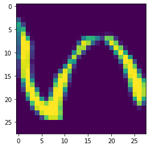

```
Range for pixel value is: ( 0 , 255 )
```

```python
sample_image = x_train[random.randint(0, len(x_train) - 1)]
plt.imshow(sample_image.reshape(28, 28))
plt.show()

print("Range for pixel value is: (", np.min(sample_image), ",", np.max(sample_image), ")")
```

## ○ بخش دو: رسم یک نمونه از تمامی کلاس‌های موجود

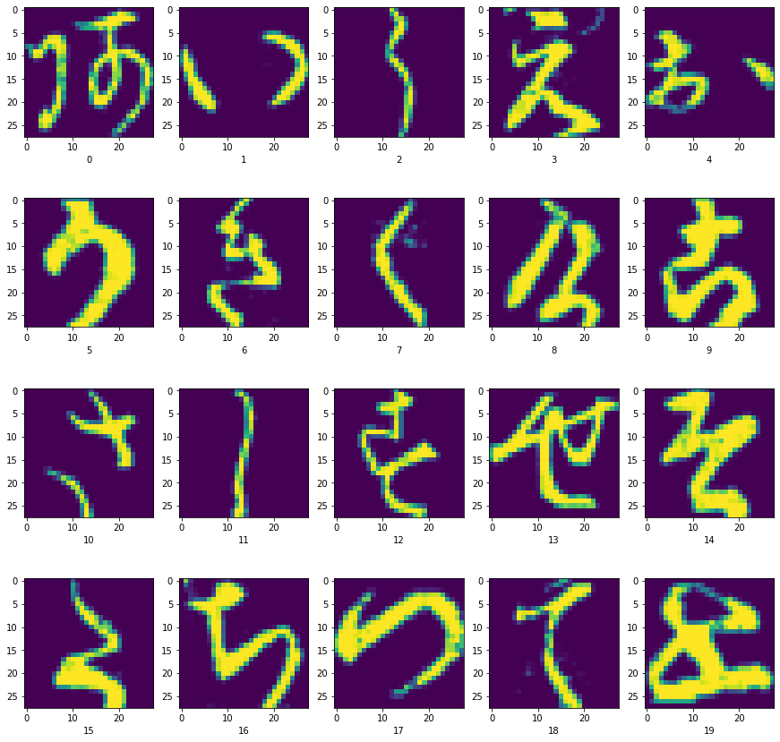

```python
class_list = list(np.unique(y_train))
index = []

for i in range(len(y_train)):
    if class_list:
        if y_train[i] == class_list[0]:
            index.append(i)
            class_list.remove(class_list[0])
    else:
        break

index = np.array(index).reshape(4, 5)
fig, ax = plt.subplots(nrows = 4, ncols = 5, figsize=(15,15))

for ix, iy in np.ndindex(index.shape):
    ax[ix, iy].imshow(x_train[index[ix, iy]].reshape(28, 28))
    ax[ix, iy].set_xlabel(y_train[index[ix, iy]][0])

plt.show()
```

## ○ بخش سه: رسم نمودار هیستوگرام فراوانی نمونه‌های هر کلاس

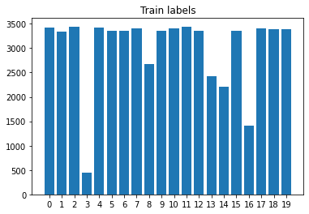

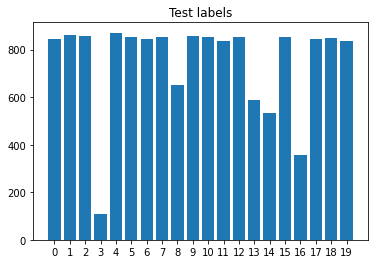

```python
x_test = pd.read_csv('dataset/test_images.csv')
x_test = x_test.drop(x_test.columns[0], axis=1)
x_test = x_test.to_numpy()

y_test = pd.read_csv('dataset/test_labels.csv')
y_test = y_test.drop(y_test.columns[0], axis=1)
y_test = y_test.to_numpy()

x_train_stats = np.unique(y_train, return_counts=True)
x_train_stats_labels = [str(i) for i in x_train_stats[0]]
x_test_stats = np.unique(y_test, return_counts=True)

plt.bar(x_train_stats_labels, x_train_stats[1])
plt.title('Train labels')
plt.show()

x_test_stats_labels = [str(i) for i in x_test_stats[0]]
plt.bar(x_test_stats_labels, x_test_stats[1])
plt.title('Test labels')
plt.show()
```

```python
train_data = np.array(np.loadtxt("./dataset/train_images.csv", delimiter = ',')[:,1:], dtype = float)
train_labels = np.array(np.loadtxt("./dataset/train_labels.csv", delimiter = ',')[:,1], dtype = int)
test_data = np.array(np.loadtxt("./dataset/test_images.csv", delimiter = ',')[:,1:], dtype = float)
test_labels = np.array(np.loadtxt("./dataset/test_labels.csv", delimiter = ',')[:,1], dtype = int)
```

## ○ بخش چهار: نرمالیزه کردن داده‌ها:

دلیل این کار این است که دیتاهای بزرگ باعث می‌شوند عملیات همگرایی بیش‌تر طول بکشد و همچنین ممکن است داده‌ها بزرگ‌ و بزرگ‌تر شده و overflow رخ بدهد به همین علت، ما از نرمال کردن داده‌ها در ابتدای کار استفاده می‌کنیم.

```python
train_data = train_data/255
test_data = test_data/255
```

## ○ در این فاز قسمت‌های ناقص شبکه عصبی مطابق خواسته صورت پروژه، تکمیل شد.

## ● فاز سوم

```python
BATCH = 64
EPOCHS = 20
INPUT_SHAPE = 784
LEARNING_RATE = 0.001

trainloader = Dataloader(train_data, train_labels, n_classes = 20, batch_size = BATCH)
testloader = Dataloader(test_data, test_labels, n_classes = 20, batch_size = BATCH)
```

## ○ بخش یک: آموزش شبکه

```python
network = FeedForwardNN(INPUT_SHAPE)
network.add_layer(80, activation = Relu(), initial_weight = 'uniform')
network.add_layer(20, activation = Relu(), initial_weight = 'uniform')
network.add_layer(80, activation = Relu(), initial_weight = 'uniform')
network.add_layer(20, activation = Identical(), initial_weight = 'uniform')
network.set_training_param(loss = CrossEntropy(), lr = LEARNING_RATE)

log_1 = network.fit(EPOCHS, trainloader, testloader)
```

```
Epoch 1:
	Train: Average Accuracy: 0.0859677868773018	Average Loss: 2.88848108984733
	Test: Average Accuracy: 0.14522074468085105	Average Loss: 2.6090938085885065
Epoch 2:
	Train: Average Accuracy: 0.2265720908444789	Average Loss: 2.313522581358511
	Test: Average Accuracy: 0.23247872340425532	Average Loss: 2.339445816500805
Epoch 3:
	Train: Average Accuracy: 0.3135519642049493	Average Loss: 2.0740444700204845
	Test: Average Accuracy: 0.3298563829787234	Average Loss: 2.0632724391927315
Epoch 4:
	Train: Average Accuracy: 0.4538094834270207	Average Loss: 1.6604638390587039
	Test: Average Accuracy: 0.45626063829787233	Average Loss: 1.7683846376729482
Epoch 5:
	Train: Average Accuracy: 0.6253442608386639	Average Loss: 1.2326336287593498
	Test: Average Accuracy: 0.5686728723404255	Average Loss: 1.4480885973703226
Epoch 6:
	Train: Average Accuracy: 0.7087947034308973	Average Loss: 0.980367789698333
	Test: Average Accuracy: 0.6275239361702127	Average Loss: 1.263903390150841
Epoch 7:
	Train: Average Accuracy: 0.7547525158299412	Average Loss: 0.826696144080321
	Test: Average Accuracy: 0.6614414893617021	Average Loss: 1.152347878646911
Epoch 8:
	Train: Average Accuracy: 0.7887510499450798	Average Loss: 0.7152868934520562
	Test: Average Accuracy: 0.6908962765957447	Average Loss: 1.053155709121433
Epoch 9:
	Train: Average Accuracy: 0.8149703996252504	Average Loss: 0.6242115216159397
	Test: Average Accuracy: 0.7189255319148936	Average Loss: 0.971666993564321
Epoch 10:
	Train: Average Accuracy: 0.8363579828132067	Average Loss: 0.5514103050421003
	Test: Average Accuracy: 0.7387021276595744	Average Loss: 0.9175626283695465
Epoch 11:
	Train: Average Accuracy: 0.8556310371842089	Average Loss: 0.4920981119055204
	Test: Average Accuracy: 0.7588484042553192	Average Loss: 0.8623360030361131
Epoch 12:
	Train: Average Accuracy: 0.8702399124507333	Average Loss: 0.4438373988825499
	Test: Average Accuracy: 0.7688510638297873	Average Loss: 0.8288764972042787
Epoch 13:
	Train: Average Accuracy: 0.8824667248174711	Average Loss: 0.4040973132662268
	Test: Average Accuracy: 0.778595744680851	Average Loss: 0.7938751401063185
Epoch 14:
	Train: Average Accuracy: 0.8924760329844286	Average Loss: 0.37086959070631104
	Test: Average Accuracy: 0.7840186170212765	Average Loss: 0.7810671921079454
Epoch 15:
	Train: Average Accuracy: 0.9010204658525555	Average Loss: 0.3422760103285988
	Test: Average Accuracy: 0.7898031914893616	Average Loss: 0.7808762247558078
Epoch 16:
	Train: Average Accuracy: 0.9086007664599083	Average Loss: 0.3178224319113554
	Test: Average Accuracy: 0.7976489361702127	Average Loss: 0.7576541543073304
Epoch 17:
	Train: Average Accuracy: 0.9150286513859275	Average Loss: 0.2961219393911543
	Test: Average Accuracy: 0.7992446808510638	Average Loss: 0.7600942156292749
Epoch 18:
	Train: Average Accuracy: 0.9201425906183369	Average Loss: 0.2764812747337427
	Test: Average Accuracy: 0.7991781914893616	Average Loss: 0.7712260274391605
Epoch 19:
	Train: Average Accuracy: 0.9247234808102346	Average Loss: 0.25992080320909555
	Test: Average Accuracy: 0.8017712765957447	Average Loss: 0.7750946350833691
Epoch 20:
	Train: Average Accuracy: 0.9292710554371002	Average Loss: 0.24470136902979728
	Test: Average Accuracy: 0.8040026595744681	Average Loss: 0.783466657010946
```

## ○ بخش دو: وزن‌دهی شبکه

هنگامی که تمام وزن‌ها و بایاس‌ها با مقادیر صفر مقداردهی اولیه می‌شوند، مشتق تابع loss function با توجه به تمام وزن‌ها و بایاس‌ها در هر لایه یکسان و بی‌تغییر خواهد بود. بنابراین، همه وزن‌ها در تکرارهای بعدی مقدار یکسانی خواهند داشت و این امر باعث می‌شود که لایه‌های پنهان متقارن شوند و شبکه عصبی بهتر از یک مدل خطی عمل نکند در نتیجه مقداردهی اولیه وزن‌های شبکه با صفر، کار مغقولی به نظر نمی‌رسد.

## ○ بخش سه: تاثیر learning rate

learning rate کم می‌تواند زمان همگرایی را به طرز چشمگیری افزایش دهد در حالی که استفاده از learning rate بزرگ نیز می تواند منجر به از دست دادن مناطق مطلوب در شبکه شود؛ در نتیجه، انتخاب درست این متغیر، برای افزایش کیفیت عملکرد شبکه ضروری است.

```python
accuracy_lr, loss_lr = [[], []], [[], []]
lr_ranges = [0.001, 0.0001, 0.01]

for lr in lr_ranges:
    print(colored('learning rate is:', 'red'), colored(lr, 'red'))

    temp_trainloader = Dataloader(train_data, train_labels, n_classes = 20, batch_size = BATCH)
    temp_testloader = Dataloader(test_data, test_labels, n_classes = 20, batch_size = BATCH)

    temp_network = FeedForwardNN(INPUT_SHAPE)
    temp_network.add_layer(80, activation = Relu(), initial_weight = 'uniform')
    temp_network.add_layer(20, activation = Relu(), initial_weight = 'uniform')
    temp_network.add_layer(80, activation = Relu(), initial_weight = 'uniform')
    temp_network.add_layer(20, activation = Identical(), initial_weight = 'uniform')
    temp_network.set_training_param(loss = CrossEntropy(), lr = lr)

    temp_log = temp_network.fit(EPOCHS, temp_trainloader, temp_testloader)

    loss_lr[0].append(temp_log["train_loss"][-1])
    loss_lr[1].append(temp_log["test_loss"][-1])
    accuracy_lr[0].append(temp_log["train_accuracy"][-1])
    accuracy_lr[1].append(temp_log["test_accuracy"][-1])

    print()
```

```
learning rate is: 0.001
Epoch 1:
	Train: Average Accuracy: 0.10510455030044583	Average Loss: 2.815326246458659
	Test: Average Accuracy: 0.16321010638297875	Average Loss: 2.500518513548198
Epoch 2:
	Train: Average Accuracy: 0.23958181898946826	Average Loss: 2.2522196807574244
	Test: Average Accuracy: 0.244218085106383	Average Loss: 2.2613012171539
Epoch 3:
	Train: Average Accuracy: 0.3898602563481295	Average Loss: 1.8577148338248928
	Test: Average Accuracy: 0.43086170212765956	Average Loss: 1.8756128716109612
Epoch 4:
	Train: Average Accuracy: 0.587069724429799	Average Loss: 1.3461177715508739
	Test: Average Accuracy: 0.536093085106383	Average Loss: 1.5589409670770966
Epoch 5:
	Train: Average Accuracy: 0.6935058877689475	Average Loss: 1.02505699501981
	Test: Average Accuracy: 0.6102872340425533	Average Loss: 1.3180891093953806
Epoch 6:
	Train: Average Accuracy: 0.7500080765006139	Average Loss: 0.8404391589879183
	Test: Average Accuracy: 0.6625265957446809	Average Loss: 1.1605080780333663
Epoch 7:
	Train: Average Accuracy: 0.7858379571299346	Average Loss: 0.7246804697330474
	Test: Average Accuracy: 0.6858643617021276	Average Loss: 1.0664347334353343
Epoch 8:
	Train: Average Accuracy: 0.8140219155844155	Average Loss: 0.633635350705372
	Test: Average Accuracy: 0.7135691489361702	Average Loss: 0.9750605171599702
Epoch 9:
	Train: Average Accuracy: 0.835359525424824	Average Loss: 0.5577805691136045
	Test: Average Accuracy: 0.7357101063829787	Average Loss: 0.8966627411855039
Epoch 10:
	Train: Average Accuracy: 0.8539162951476384	Average Loss: 0.49728200173755654
	Test: Average Accuracy: 0.7543936170212766	Average Loss: 0.8385778182624586
Epoch 11:
	Train: Average Accuracy: 0.8679234711184338	Average Loss: 0.4505655835005076
	Test: Average Accuracy: 0.7696196808510638	Average Loss: 0.8011764226215774
Epoch 12:
	Train: Average Accuracy: 0.879150816534212	Average Loss: 0.41321100773968483
	Test: Average Accuracy: 0.7798590425531915	Average Loss: 0.778422233761187
Epoch 13:
	Train: Average Accuracy: 0.8882792813529754	Average Loss: 0.38217832948113345
	Test: Average Accuracy: 0.7910292553191489	Average Loss: 0.7429456440631272
```

[output cut: 130 more lines]

```
Epoch 16:
	Train: Average Accuracy: 0.05555067600310138	Average Loss: 2.951616889551944
	Test: Average Accuracy: 0.056789893617021275	Average Loss: 2.950327071823628
Epoch 17:
	Train: Average Accuracy: 0.05555067600310138	Average Loss: 2.951616889551944
	Test: Average Accuracy: 0.056789893617021275	Average Loss: 2.950327071823628
Epoch 18:
	Train: Average Accuracy: 0.05555067600310138	Average Loss: 2.951616889551944
	Test: Average Accuracy: 0.056789893617021275	Average Loss: 2.950327071823628
Epoch 19:
	Train: Average Accuracy: 0.05555067600310138	Average Loss: 2.951616889551944
	Test: Average Accuracy: 0.056789893617021275	Average Loss: 2.950327071823628
Epoch 20:
	Train: Average Accuracy: 0.05555067600310138	Average Loss: 2.951616889551944
	Test: Average Accuracy: 0.056789893617021275	Average Loss: 2.950327071823628
```

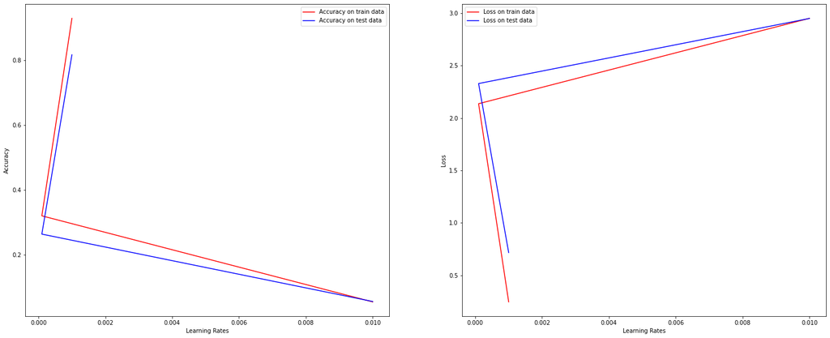

```python
#Plot
fig, (ax1, ax2) = plt.subplots(1, 2, figsize=(25, 10))

ax1.plot(lr_ranges, accuracy_lr[0], color = 'red',  label = 'Accuracy on train data')
ax1.plot(lr_ranges, accuracy_lr[1], color = 'blue', label = 'Accuracy on test data')
ax1.set_xlabel("Learning Rates")
ax1.set_ylabel("Accuracy")
ax1.legend()

ax2.plot(lr_ranges, loss_lr[0], color = 'red',  label = 'Loss on train data')
ax2.plot(lr_ranges, loss_lr[1], color = 'blue', label = 'Loss on test data')
ax2.set_xlabel("Learning Rates")
ax2.set_ylabel('Loss')
ax2.legend()
```

## ○ بخش چهار: تاثیر Activation Function

● عملکرد ضعیف Sigmoid به این دلیل است که خروجی Sigmoid برای یک عدد مثبت یا منفی بزرگ اشباع می‌شود بنابراین، gradient در این مناطق تقریباً برابر صفر است. در هنگام backpropagation، مقدار gradient محلی در gradient خروجی gateها ضرب می‌شود و اگر gradient محلی بسیار کوچک باشد، gradient کل را از بین می برد و شبکه یاد نمی گیرد. این مشکل توسط ReLU حل شده است. در tanh هم همین مورد هست اما دلیل اینکه tanh در مقایسه با Sigmoid نتایج بهتری دارد بزرگتر بودن مشتقات tanh از مشتقات Sigmoid است. به عبارت دیگر ، اگر از tanh به عنوان activation Function استفاده شود، تابع هزینه خود را سریعتر مینیمم می کنیم.

```python
accuracy_af, loss_af = [[], []], [[], []]
activation_funcs = [Relu(), Sigmoid(), Tanh(), LeakyRelu()]
activation_funcs_name = ["Relu", "Sigmoid", "Tanh", "LeakyRelu"]
activation_funcs_num = [1, 2, 3, 4]

for i in range(len(activation_funcs)):
    print(colored('Activation function is:', 'red'), colored(activation_funcs_name[i], 'red'))

    temp_trainloader = Dataloader(train_data, train_labels, n_classes = 20, batch_size = BATCH)
    temp_testloader = Dataloader(test_data, test_labels, n_classes = 20, batch_size = BATCH)

    temp_network = FeedForwardNN(INPUT_SHAPE)
    temp_network.add_layer(80, activation = activation_funcs[i], initial_weight = 'uniform')
    temp_network.add_layer(20, activation = activation_funcs[i], initial_weight = 'uniform')
    temp_network.add_layer(80, activation = activation_funcs[i], initial_weight = 'uniform')
    temp_network.add_layer(20, activation = Identical(), initial_weight = 'uniform')
    temp_network.set_training_param(loss = CrossEntropy(), lr = LEARNING_RATE)

    temp_log = temp_network.fit(EPOCHS, temp_trainloader, temp_testloader)

    loss_af[0].append(temp_log["train_loss"][-1])
    loss_af[1].append(temp_log["test_loss"][-1])
    accuracy_af[0].append(temp_log["train_accuracy"][-1])
    accuracy_af[1].append(temp_log["test_accuracy"][-1])

    print()
```

```
Activation function is: Relu
Epoch 1:
	Train: Average Accuracy: 0.10363866543903857	Average Loss: 2.8129691332337825
	Test: Average Accuracy: 0.1748457446808511	Average Loss: 2.4717634619593385
Epoch 2:
	Train: Average Accuracy: 0.24697787442656846	Average Loss: 2.249557235458661
	Test: Average Accuracy: 0.24701063829787234	Average Loss: 2.302179761574531
Epoch 3:
	Train: Average Accuracy: 0.34998152500484586	Average Loss: 1.9686313373460478
	Test: Average Accuracy: 0.3581143617021277	Average Loss: 2.034298060555842
Epoch 4:
	Train: Average Accuracy: 0.5287165027137042	Average Loss: 1.4844240952370624
	Test: Average Accuracy: 0.5041489361702127	Average Loss: 1.6355976727431591
Epoch 5:
	Train: Average Accuracy: 0.6598925017768302	Average Loss: 1.1085964451154167
	Test: Average Accuracy: 0.6101037234042552	Average Loss: 1.3235165008879135
Epoch 6:
	Train: Average Accuracy: 0.7359332598371777	Average Loss: 0.8774736676310553
	Test: Average Accuracy: 0.6481728723404255	Average Loss: 1.1825753009511815
Epoch 7:
	Train: Average Accuracy: 0.774978092492085	Average Loss: 0.7522816306931104
	Test: Average Accuracy: 0.6864122340425531	Average Loss: 1.060070247944124
Epoch 8:
	Train: Average Accuracy: 0.8047758367254636	Average Loss: 0.6586807176718342
	Test: Average Accuracy: 0.7102154255319149	Average Loss: 0.9851833254519441
Epoch 9:
	Train: Average Accuracy: 0.8269473452542483	Average Loss: 0.5875457841290498
	Test: Average Accuracy: 0.7320239361702128	Average Loss: 0.9293178070790986
Epoch 10:
	Train: Average Accuracy: 0.843604118207663	Average Loss: 0.5306105094927126
	Test: Average Accuracy: 0.752502659574468	Average Loss: 0.859750555283456
Epoch 11:
	Train: Average Accuracy: 0.8582286416941267	Average Loss: 0.48250192614738313
	Test: Average Accuracy: 0.7637686170212766	Average Loss: 0.8171391285241714
Epoch 12:
	Train: Average Accuracy: 0.8702222451056406	Average Loss: 0.4410913335831732
	Test: Average Accuracy: 0.7739787234042553	Average Loss: 0.7882485040721753
Epoch 13:
	Train: Average Accuracy: 0.8805334124830393	Average Loss: 0.40681379419488983
	Test: Average Accuracy: 0.783220744680851	Average Loss: 0.7570574189314639
```

[output cut: 192 more lines]

```
Epoch 16:
	Train: Average Accuracy: 0.9012703325902953	Average Loss: 0.33402216737874607
	Test: Average Accuracy: 0.7906010638297872	Average Loss: 0.7869071176991052
Epoch 17:
	Train: Average Accuracy: 0.9078334989015959	Average Loss: 0.3127822473154554
	Test: Average Accuracy: 0.7953882978723403	Average Loss: 0.773424065387216
Epoch 18:
	Train: Average Accuracy: 0.9137636694772889	Average Loss: 0.29367543689214914
	Test: Average Accuracy: 0.7999840425531916	Average Loss: 0.771865048124593
Epoch 19:
	Train: Average Accuracy: 0.9187943197971183	Average Loss: 0.2768288772354355
	Test: Average Accuracy: 0.8025106382978724	Average Loss: 0.7720904154382465
Epoch 20:
	Train: Average Accuracy: 0.9231753165988241	Average Loss: 0.26140667613750057
	Test: Average Accuracy: 0.8071276595744681	Average Loss: 0.7678426120039111
```

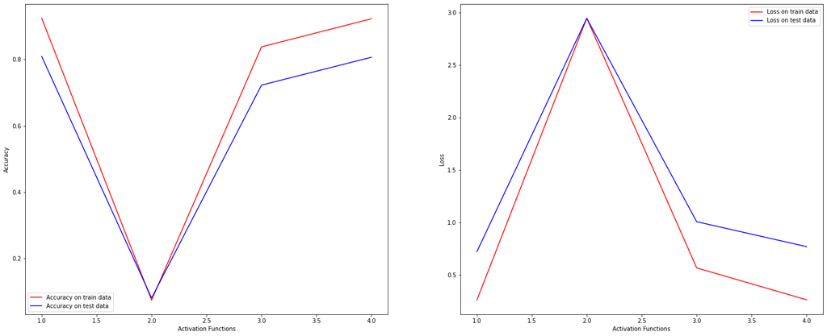

```python
#Plot
fig, (ax1, ax2) = plt.subplots(1, 2, figsize=(25, 10))

ax1.plot(activation_funcs_num, accuracy_af[0], color = 'red',  label = 'Accuracy on train data')
ax1.plot(activation_funcs_num, accuracy_af[1], color = 'blue', label = 'Accuracy on test data')
ax1.set_xlabel("Activation Functions")
ax1.set_ylabel("Accuracy")
ax1.legend()

ax2.plot(activation_funcs_num, loss_af[0], color = 'red',  label = 'Loss on train data')
ax2.plot(activation_funcs_num, loss_af[1], color = 'blue', label = 'Loss on test data')
ax2.set_xlabel("Activation Functions")
ax2.set_ylabel('Loss')
ax2.legend()
```

## ○ بخش پنج: تاثیر batch size

● به دو دلیل از batch به جای داده‌های منفرد استفاده می‌شود؛ یکی اینکه استفاده از بچ‌ها می تواند روند آموزش را تسریع کند چرا که پردازش بیشتری به طور موازی انجام می شود و دو اینکه آموزش مدل با بچ‌ها می‌تواند gradient noise ناشی از داده های منفرد را کاهش دهد و تخمینی که از gradient به دست می‌آوریم، در هر مرحله آموزش دقیق‌تر خواهد بود.

```python
accuracy_bs, loss_bs = [[], []], [[], []]
batch_sizes = [16, 32, 64, 256]

for bs in batch_sizes:
    print(colored('batch size is:', 'red'), colored(bs, 'red'))

    temp_trainloader = Dataloader(train_data, train_labels, n_classes = 20, batch_size = bs)
    temp_testloader = Dataloader(test_data, test_labels, n_classes = 20, batch_size = bs)

    temp_network = FeedForwardNN(INPUT_SHAPE)
    temp_network.add_layer(80, activation = LeakyRelu(), initial_weight = 'uniform')
    temp_network.add_layer(20, activation = LeakyRelu(), initial_weight = 'uniform')
    temp_network.add_layer(80, activation = LeakyRelu(), initial_weight = 'uniform')
    temp_network.add_layer(20, activation = Identical(), initial_weight = 'uniform')
    temp_network.set_training_param(loss = CrossEntropy(), lr = LEARNING_RATE)

    temp_log = temp_network.fit(EPOCHS, temp_trainloader, temp_testloader)

    loss_bs[0].append(temp_log["train_loss"][-1])
    loss_bs[1].append(temp_log["test_loss"][-1])
    accuracy_bs[0].append(temp_log["train_accuracy"][-1])
    accuracy_bs[1].append(temp_log["test_accuracy"][-1])

    print()
```

```
batch size is: 16
Epoch 1:
	Train: Average Accuracy: 0.12165089309517461	Average Loss: 2.749882701359411
	Test: Average Accuracy: 0.18100716654821133	Average Loss: 2.4493557559899184
Epoch 2:
	Train: Average Accuracy: 0.2631631564916022	Average Loss: 2.2089451719246944
	Test: Average Accuracy: 0.27344675432362	Average Loss: 2.248944694635913
Epoch 3:
	Train: Average Accuracy: 0.4156724873367102	Average Loss: 1.8294855259446132
	Test: Average Accuracy: 0.38751924899312956	Average Loss: 1.9426278317399015
Epoch 4:
	Train: Average Accuracy: 0.5395561183684351	Average Loss: 1.4654478917986535
	Test: Average Accuracy: 0.47973673300165837	Average Loss: 1.7133249099613577
Epoch 5:
	Train: Average Accuracy: 0.6458111170354572	Average Loss: 1.1696472193125698
	Test: Average Accuracy: 0.568489398246861	Average Loss: 1.4425888585070095
Epoch 6:
	Train: Average Accuracy: 0.7105605171954146	Average Loss: 0.9509352028752898
	Test: Average Accuracy: 0.6327070007107322	Average Loss: 1.222133599283382
Epoch 7:
	Train: Average Accuracy: 0.7652292721940815	Average Loss: 0.7833550302608493
	Test: Average Accuracy: 0.6873297204453921	Average Loss: 1.0632014519514577
Epoch 8:
	Train: Average Accuracy: 0.7987536656891495	Average Loss: 0.6792244924222098
	Test: Average Accuracy: 0.7063862236436864	Average Loss: 0.9879706957507097
Epoch 9:
	Train: Average Accuracy: 0.8181984804052252	Average Loss: 0.6126217975962479
	Test: Average Accuracy: 0.7231254442075339	Average Loss: 0.9294180950601008
Epoch 10:
	Train: Average Accuracy: 0.8347107438016529	Average Loss: 0.560562972514745
	Test: Average Accuracy: 0.7333200071073206	Average Loss: 0.8953452375701179
Epoch 11:
	Train: Average Accuracy: 0.8497733937616636	Average Loss: 0.5147561400555464
	Test: Average Accuracy: 0.7439809879175552	Average Loss: 0.863752412969599
Epoch 12:
	Train: Average Accuracy: 0.8617202079445481	Average Loss: 0.47504064021297665
	Test: Average Accuracy: 0.7533093461265103	Average Loss: 0.8438253920416313
Epoch 13:
	Train: Average Accuracy: 0.8713842975206612	Average Loss: 0.43995035680221445
	Test: Average Accuracy: 0.7641702203269368	Average Loss: 0.8141308884828342
```

[output cut: 192 more lines]

```
Epoch 16:
	Train: Average Accuracy: 0.8033340644878262	Average Loss: 0.6979779881078617
	Test: Average Accuracy: 0.6921596322144677	Average Loss: 1.1267389075478582
Epoch 17:
	Train: Average Accuracy: 0.8128360454595306	Average Loss: 0.6668933257039183
	Test: Average Accuracy: 0.6942999127617148	Average Loss: 1.119063328880093
Epoch 18:
	Train: Average Accuracy: 0.8207921487716604	Average Loss: 0.6383913724444301
	Test: Average Accuracy: 0.6979196957737898	Average Loss: 1.1105761174357323
Epoch 19:
	Train: Average Accuracy: 0.8279351283176134	Average Loss: 0.6108952421541456
	Test: Average Accuracy: 0.7093965499335327	Average Loss: 1.073568142219884
Epoch 20:
	Train: Average Accuracy: 0.83359135089932	Average Loss: 0.5890789322607008
	Test: Average Accuracy: 0.7133460728924338	Average Loss: 1.0606636753302825
```

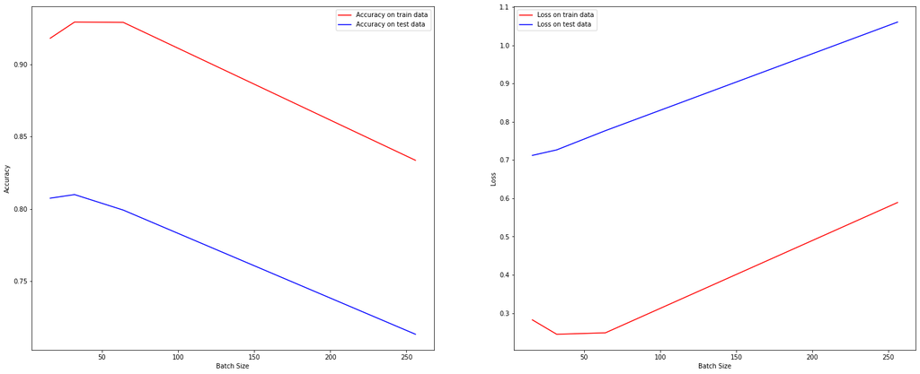

```python
#Plot
fig, (ax1, ax2) = plt.subplots(1, 2, figsize=(25, 10))

ax1.plot(batch_sizes, accuracy_bs[0], color = 'red',  label = 'Accuracy on train data')
ax1.plot(batch_sizes, accuracy_bs[1], color = 'blue', label = 'Accuracy on test data')
ax1.set_xlabel("Batch Size")
ax1.set_ylabel("Accuracy")
ax1.legend()

ax2.plot(batch_sizes, loss_bs[0], color = 'red',  label = 'Loss on train data')
ax2.plot(batch_sizes, loss_bs[1], color = 'blue', label = 'Loss on test data')
ax2.set_xlabel("Batch Size")
ax2.set_ylabel('Loss')
ax2.legend()
```

## ○ بخش شش: تاثیر epoch

● آموزش یک شبکه عصبی شامل بهینه سازی مجموعه بزرگی از پارامترهای کاملاً وابسته به هم است و بهینه‌سازی این پارامترها نیاز به حجم عظیمی از داده‌ها برای train دارد. تهیه چنین مجموعه بزرگی از داده‌ها به زمان، هزینه و فضای قابل توجهی نیاز دارد؛ بنابراین میزان نمونه‌های موجود معمولاً بسیار کمتر از تعداد نمونه های مورد نیاز می‌باشد. علاوه بر این، حتی اگر چنین حجمی از داده‌ها را داشته باشیم، ممکن است استخراج الگوریتم بهینه سازی gradient-based به زمان زیادی نیاز داشته باشد. راه حل کلی این مسئله استفاده از داده های یکسان در طول epochهای آموزشی متعدد است. این روش بدون نیاز به حجم زیاد داده، به الگوریتم زمان می‌دهد تا همگرا شود.

● افزایش epoch‌ها همواره باعث افزایش دقت نمی‌شود و در واقع از یک مقدار خاصی، دقت دیگر افزایش نمی‌یابد (به ازای تعداد بیشتر epochها)! همچنین افزایش opochها باعث می‌شود واریانس بالاتری بگیریم و دچار overfitting شویم. به طور کلی، هنگام آموزش یک شبکه بزرگ، یک نقطه عطفی وجود خواهد داشت که از آنجا مدل generalizing را متوقف می‌کند و نویزهای موجود در داده train را می‌آموزد که اینکار باعث می‌شود مدل در پیش‌بینی‌های جدید کارایی کمتری داشته باشد.

● دو مورد از روش‌هایی که برای حل این مشکل وجود دارد را بررسی می‌کنیم: مورد اول، توقف آموزش است؛ یعنی از جایی که متوجه می‌شویم، ادامه روند آموزش باعث تخریب مدل یادگیری می‌شود آن را متوقف کنیم و به epochهای بعدی نرویم. مورد دوم کاهش لایه‌های پنهان است؛ افزایش تعداد لایه‌های پنهان و نورون‌ها ممکن است باعث overfitting شود؛ چرا که باعث می‌شود قدرت به خاطر سپردن شبکه افزایش یابد.

```python
train_ep, test_ep = [], []
accuracy_ep, loss_ep = [[], []], [[], []]
epoches_range = [20, 40, 80, 100]

for ep in epoches_range:
    print(colored('epoch numeber is:', 'red'), colored(ep, 'red'))

    temp_trainloader = Dataloader(train_data, train_labels, n_classes = 20, batch_size = BATCH)
    temp_testloader = Dataloader(test_data, test_labels, n_classes = 20, batch_size = BATCH)

    temp_network = FeedForwardNN(INPUT_SHAPE)
    temp_network.add_layer(80, activation = Relu(), initial_weight = 'uniform')
    temp_network.add_layer(20, activation = Relu(), initial_weight = 'uniform')
    temp_network.add_layer(80, activation = Relu(), initial_weight = 'uniform')
    temp_network.add_layer(20, activation = Identical(), initial_weight = 'uniform')
    temp_network.set_training_param(loss = CrossEntropy(), lr = LEARNING_RATE)

    temp_log = temp_network.fit(ep, temp_trainloader, temp_testloader)

    loss_ep[0].append(temp_log["train_loss"][-1])
    loss_ep[1].append(temp_log["test_loss"][-1])
    accuracy_ep[0].append(temp_log["train_accuracy"][-1])
    accuracy_ep[1].append(temp_log["test_accuracy"][-1])

    print()
```

```
epoch numeber is: 20
Epoch 1:
	Train: Average Accuracy: 0.08575123570459392	Average Loss: 2.94039973988198
	Test: Average Accuracy: 0.09375797872340424	Average Loss: 2.8373188009657606
Epoch 2:
	Train: Average Accuracy: 0.1804966644052465	Average Loss: 2.520620253185153
	Test: Average Accuracy: 0.20744148936170212	Average Loss: 2.477505529020028
Epoch 3:
	Train: Average Accuracy: 0.25848739258254183	Average Loss: 2.2726264208609646
	Test: Average Accuracy: 0.2601090425531915	Average Loss: 2.314735736071133
Epoch 4:
	Train: Average Accuracy: 0.33002752067584157	Average Loss: 2.0388727980794794
	Test: Average Accuracy: 0.3265398936170213	Average Loss: 2.0891389216310756
Epoch 5:
	Train: Average Accuracy: 0.4608703640886477	Average Loss: 1.6269094773463006
	Test: Average Accuracy: 0.45909042553191487	Average Loss: 1.7279598111255134
Epoch 6:
	Train: Average Accuracy: 0.6266789025650966	Average Loss: 1.1768261805659943
	Test: Average Accuracy: 0.5729946808510639	Average Loss: 1.3950470267758472
Epoch 7:
	Train: Average Accuracy: 0.7293887704335467	Average Loss: 0.8875636212935822
	Test: Average Accuracy: 0.6528351063829787	Average Loss: 1.1586197834326468
Epoch 8:
	Train: Average Accuracy: 0.7813247076306777	Average Loss: 0.7291163642645733
	Test: Average Accuracy: 0.6978484042553191	Average Loss: 1.0349454328874312
Epoch 9:
	Train: Average Accuracy: 0.8123894528978484	Average Loss: 0.6282020102434633
	Test: Average Accuracy: 0.7256409574468085	Average Loss: 0.9454787265166685
Epoch 10:
	Train: Average Accuracy: 0.8370909252439103	Average Loss: 0.5519546791036939
	Test: Average Accuracy: 0.7455292553191489	Average Loss: 0.8802588839037833
Epoch 11:
	Train: Average Accuracy: 0.8556643527492408	Average Loss: 0.4903515614544884
	Test: Average Accuracy: 0.761686170212766	Average Loss: 0.8405537177903512
Epoch 12:
	Train: Average Accuracy: 0.8705877067584158	Average Loss: 0.44226564840961846
	Test: Average Accuracy: 0.7748138297872341	Average Loss: 0.805799627320166
Epoch 13:
	Train: Average Accuracy: 0.8813839689539317	Average Loss: 0.40226562798872695
	Test: Average Accuracy: 0.7849202127659575	Average Loss: 0.7728915394417036
```

[output cut: 672 more lines]

```
Epoch 96:
	Train: Average Accuracy: 0.9884894722814499	Average Loss: 0.03625681217858705
	Test: Average Accuracy: 0.8201968085106384	Average Loss: 1.757980252199002
Epoch 97:
	Train: Average Accuracy: 0.9907216151385928	Average Loss: 0.02734061509748185
	Test: Average Accuracy: 0.812875	Average Loss: 1.8117209586326615
Epoch 98:
	Train: Average Accuracy: 0.9886393923240938	Average Loss: 0.03520889902535108
	Test: Average Accuracy: 0.8173005319148937	Average Loss: 1.815928139755665
Epoch 99:
	Train: Average Accuracy: 0.9870069296375267	Average Loss: 0.041150157506223785
	Test: Average Accuracy: 0.8122473404255319	Average Loss: 1.8470187829409
Epoch 100:
	Train: Average Accuracy: 0.9849257163856044	Average Loss: 0.04645892662721569
	Test: Average Accuracy: 0.8147074468085107	Average Loss: 1.846724409819315
```

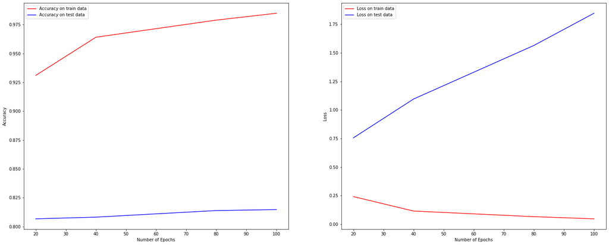

```python
#Plot
fig, (ax1, ax2) = plt.subplots(1, 2, figsize=(25, 10))

ax1.plot(epoches_range, accuracy_ep[0], color = 'red',  label = 'Accuracy on train data')
ax1.plot(epoches_range, accuracy_ep[1], color = 'blue', label = 'Accuracy on test data')
ax1.set_xlabel("Number of Epochs")
ax1.set_ylabel("Accuracy")
ax1.legend()

ax2.plot(epoches_range, loss_ep[0], color = 'red',  label = 'Loss on train data')
ax2.plot(epoches_range, loss_ep[1], color = 'blue', label = 'Loss on test data')
ax2.set_xlabel("Number of Epochs")
ax2.set_ylabel('Loss')
ax2.legend()
```